# Стратегия Giga Momentum

# Введение

Исследование эффекта моментума на фондовых рынках является одним из ключевых направлений в области финансов и инвестиций. За десятилетия его существования этот феномен привлек внимание многих исследователей, а их работы помогли сформировать базовые представления о поведении цен на финансовых рынках.

Основными исследователями эффекта моментума принято считать следующие работы:

- [Jegadeesh, Titman Returns to Buying Winners and Selling Losers: Implications for Stock Market Efficiency (1993)](https://www.jstor.org/stable/2328882) в котором они обнаружили сильный эффект моментума на краткосрочных горизонтах.
- [Carhart, On Persistence in Mutual Fund Performance (1997)](https://www.jstor.org/stable/2329556) добавил в модель Фама-Френча дополнительный фактор - моментума, который позволял значительно улучшить объяснение аномальных доходностей некоторых акций.

Эффект моментума в инвестиционной стратегии представляет собой явление, при котором активы, проявившие сильную доходность в прошлом, имеют тенденцию продолжить свой положительный тренд в будущем.

Эффект моментума остается одним из важных явлений на финансовых рынках, и стратегии, основанные на этом эффекте, привлекают внимание инвесторов т.к. он имеет свои преимущества (но и естестевенно ограничения).

#### Преимущества:

- Потенциал для высокой доходности в условиях устойчивости трендов на рынке.
- Динамическое ребалансирование позволяет быстро реагировать на изменения в моменте активов.

#### Ограничения:

- Низкая эффективность в периодах рыночной неопределенности.
- Риск возможного оверфитинга, особенно если не проводится тщательное тестирование стратегии на различных рыночных условиях.
- Риск ликвидности, связанный с эффективным исполнением стратегии

## 1. Учет длинной памяти микроструктуры в стратегии Моментума

В современном финансовом мире стратегии моментума становятся все более популярными, особенно при использовании микроструктурных данных. Однако, помимо традиционного технического анализа, учет долгосрочной памяти в микроструктурных характеристиках рынка приобретает важность. Для более глубокого понимания этой связи, мы обратим внимание на ключевые факты, выявленные в исследованиях:

- [Lillo, Farmer The Long Memory of the Efficient Market (2003).](https://arxiv.org/pdf/cond-mat/0311053.pdf)
- [Cont, Kukanov, Stoikov The price impact of order book events (2011)](https://arxiv.org/pdf/1011.6402.pdf)
- [Arbuzov, Frolova Market Liquidity Measurement and Econometric Modeling (2012).](https://link.springer.com/chapter/10.1007/978-3-642-27931-7_5)

В своей статье ставшей уже классичесокй Лилло и Фармер утверджают, что долгосрочная память может быть ключевым фактором, противоречащим идеям эффективного рынка, а поток заявок на рынке является не пуассоновским, а процессом имеющим длинную память. Одним из исследуемых ими стилизованных фактов является длинная память в потоке заявок в том, числе и рыночных - таким образом и если на рынке присутствует дисбаланс, он также будет иметь длинную память. Несмотря на определенную разницу, что в исходной работе дисбаланс считается по количеству сделок, в данных AlgoPack тоже рассчитан дисбаланс по объему сделок. Далее мы построим график, который бы показывал, что исследование зарубежных авторов применимо и к отечественному рынку.

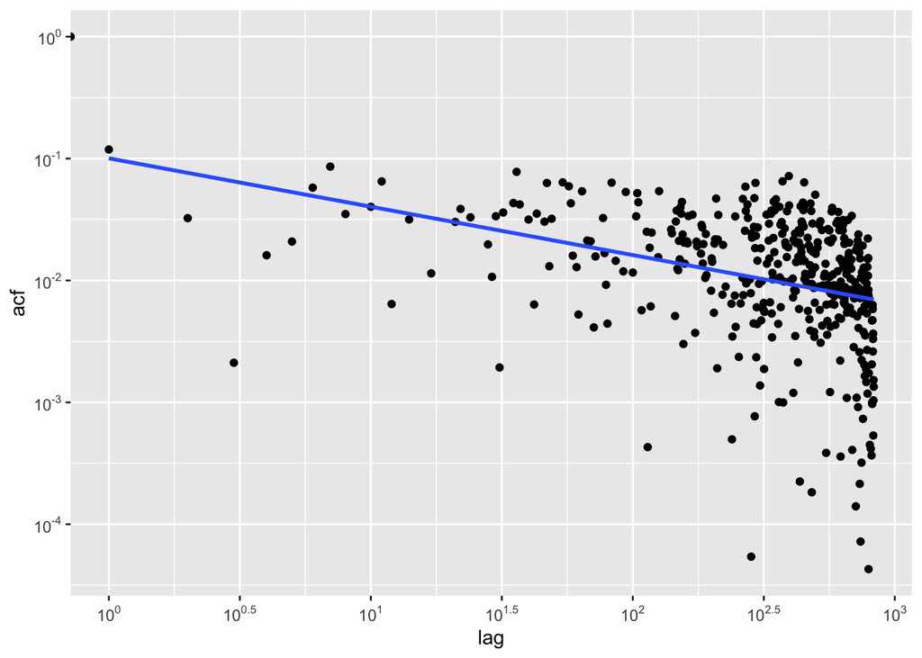

```r
# install.packages(ggplot2)
# install.packages(scales)
# devtools::install_github("arbuzovv/rusquant")

library(rusquant)
library(ggplot2)
library(scales)
tradestat_data = getSymbols.Algopack('GAZP',from = '2023-11-11',to='2023-11-24',type='tradestats')

acf_data = acf(as.numeric(tradestat_data$disb),lag.max = 1000,plot = F)

pl = data.table(acf_data$acf[acf_data$acf>0],acf_data$lag[acf_data$acf>0])
names(pl) = c('acf','lag')

ggplot(data = pl, aes(y = acf,x=lag))+
  geom_point()+ylim(0.001,1)+
 scale_x_log10("lag",
        breaks = trans_breaks("log10", function(x) 10^x),
        labels = trans_format("log10", math_format(10^.x))) +
  scale_y_log10("acf",
        breaks = trans_breaks("log10", function(x) 10^x),
        labels = trans_format("log10", math_format(10^.x))) + geom_smooth(method = lm, se = F)
```

Полученные результаты подтверждают долгосрочную память, в дисбалансе. Кроме того, следует заметить, что в следующем исследовании Стоикова утверждается, что дисбаланс в заявках и дисбаланс в сделках связан положительно с будущим приростом цен, при этом авторы приходят к выводу, что поток дисбаланс в потоках заявок сильнее определяет будущие движения цен.

Кроме того, того стоит отметь исследование Арбузова и Фроловой в которой исследуются различные метрики ликвидности, в том числе и дисбаланс в сжатости книги заявок и выявляет положительная связь с будущим приростом цен.

*Основные выводы академической литературы:*

- различные микроструктурные характеристики связанные с потоком заявок имеют длинную память
- дисбаланс в заявках, сделках и прочих характеристиках ликвидности связанны будущим приростом цены

Стратегии моментума, с учетом этих исследования, приобретают новый уровень глубины и точности, включая в себя учет длинной памяти в этих характеристиках. Длинная память, или долгосрочная зависимость, в контексте микроструктурных данных означает сохранение во времени особенностей, которые влияют на динамику цен и торговлю.

Таким образом мы разрабатываем моментум стратегию, которые представляем из себя связь между 2 хорошо изученными эффектами и объединяем это в стратегию, которую назвали **GigaMomentum**

## 2. Построение GigaMomentum стратегии

В данной главе мы опишем шаг за шагом этапы количественного исследования моментум эффекта с учетом дисбаланса в торгах

### 2.1 Загрузка необходимых справочников

Подключим необходимые библиотеки (если их нет - предварительно необходимо установить) и загрузим необходимые справочники информации.

```r
library(rusquant)
library(PerformanceAnalytics)
library(data.table)
library(caret)
tech_fields = getSymbolList('gigapack',type = 'tech')
candles_fields = getSymbolList('gigapack',type = 'candles')
moex_stock_universe = getSymbolList(src='moex')
```

### 2.2 Формирование списка ликвидных акций

Для построения успешной торговой стратегии важно выбрать активы с высокой ликвидностью, поскольку это обеспечивает легкость входа и выхода с позиций без значительного влияния на цену актива. В данном исследовании ликвидность измеряется по разнице между лучшими ценами покупки и продажи, выраженной в виде спреда.

```r
library(rusquant)
library(PerformanceAnalytics)
library(data.table)
library(caret)

tech_fields = getSymbolList('gigapack',type = 'tech')
candles_fields = getSymbolList('gigapack',type = 'candles')
moex_stock_universe = getSymbolList(src='moex')
```

### 2.3 Отбор ликвидных акций

Сначала формируется список всех акций из доступных данных, и для каждой акции вычисляется значение спреда между лучшими ценами на покупку и продажу (bid-ask spread). Затем происходит отбор акций, у которых значение спреда менее 10 б.п.. Этот критерий позволяет выделить активы с относительно высокой ликвидностью, что является важным аспектом для успешного внедрения стратегии моментума.

Таким образом, отбор ликвидных акций способствует формированию портфеля, включающего активы, которые обладают способностью быстро реагировать на изменения рыночных условий, что в свою очередь улучшает общую доходность стратегии.

```r
liquidity_universe = getSymbols.Gigapack(paste(moex_stock_universe$SECID,collapse = ','),date='2020-01-03',field = 'spread_bbo.q80',type = 'candles')
liquidity_universe = liquidity_universe[spread_bbo.q80<10]
universe = liquidity_universe$symbol
```

### 2.4 Получение данных из технических индикаторов и микроструктурных характеристик

Для построения торговой стратегии необходимо объединить данные из различных источников, таких как технические индикаторы и микроструктурные характеристики. В данном исследовании используются данные из из AlgoPack.

Технические индикаторы: В качестве индикатора оценивающего эффект моментума используется стохастический осциллятор или коротко [стохастик](https://www.fmlabs.com/reference/default.htm?url=StochasticOscillator.htm) (берется классически сет параметров 14,3,3 и сигнальная линия в качестве источника сигнала) Микроструктурные характеристики: Получаются данные из AlgoPack, в данном случае, используется дисбаланс в книге заявок (imbalance_vol.median), хотя можно было бы выбрать и дисбаланс в совершенных сделках - здесь мы выбор конкретной метрики дисбаланса оставляем за читателем.

```r
# get data from technical indicators
trading_data = getSymbols.Gigapack(paste(universe,collapse = ','),field = 'stoch,close', type = 'tech')
# get data from microstructure indicators
algo_pack_data = getSymbols.Gigapack(paste(universe,collapse = ','),field = 'imbalance_vol.median',type = 'candles')
trading_data = merge(trading_data,algo_pack_data,by = c('date','symbol'))
```

### 2.5 Ранжирование и формирование портфеля

После объединения данных происходит ранжирование акций по двум критериям: уровню дисбаланса в книге заявок (imbalance_vol.median) и значению стохастического осциллятора (stoch) для Giga Momentuma и только по стохастику для Pure Momentum. Затем рассчитывается общий ранг для каждой акции в каждый день.

На основе общего ранга выбираются топ-N акций для формирования портфеля. Далее, рассчитывается следующая дневная доходность (next_ret) и создается торговый портфель, включающий информацию о выбранных акциях, их доходности и позициях.

```r
# merge data
trading_data[,next_ret:=shift(close/shift(close,1)-1,-1),by='symbol']
trading_data[,imbalance_rank:=frank(imbalance_vol.median),by='date']
trading_data[,indicator_rank:=frank(stoch),by='date']
trading_data[,total_rank:=imbalance_rank+indicator_rank,by='date']
trading_data = na.omit(trading_data)
```

### 2.6 Оценка Pure Momentum

Для оценки торговой стратегии без учета микроструктурных эффектов (которую мы назвали Pure Momentum) выберем количество позиций которое мы будем удерживать каждый день в выбранных акциях. В данной стратегии мы выбираем 4 лучших акции с наибольшим скором (таким образом каждой позиции у нас будет по 25% в портфеле, что соответсвует достаточному уровню диверсификации для минимизации идисинкратических рисков). Кроме того мы учитываем и торговые комисии и принимаем их 5 б.п., что соответсвует средним издержкам на хорошо ликвидных акциях выбранных нами.

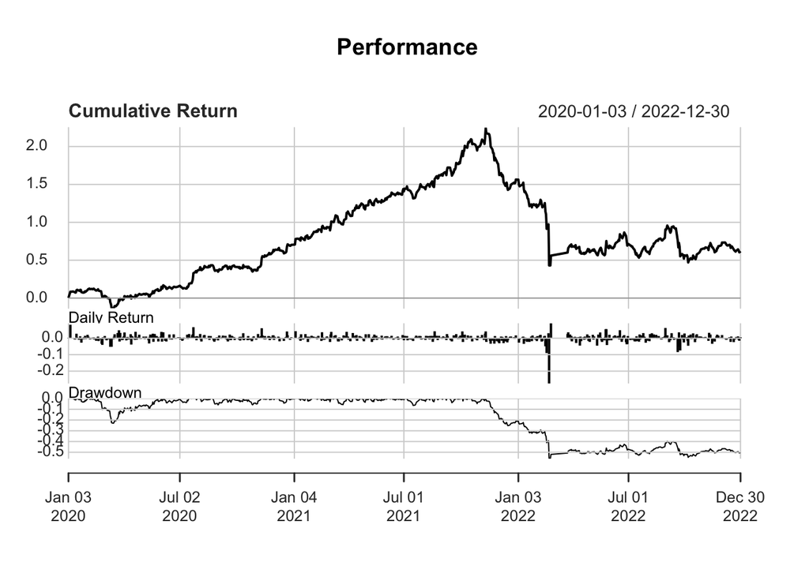

```r
# merge data
trading_data = trading_data[order(date,-indicator_rank)]
number_op_positions = 4 # choose number of position
#pnl = trading_data[,mean(next_ret[1:number_op_positions]),by=date]
trading_portfolio = trading_data[,list(symbol = symbol[1:number_op_positions],
                   pnl = next_ret[1:number_op_positions]/number_op_positions,
                   position = 1,
                   total_rank = total_rank[1:number_op_positions]),by=date]

# add cost for each day rebalancing
full_date_symbol = expand.grid(date = unique(trading_portfolio$date),
            symbol = unique(trading_portfolio$symbol))


trading_portfolio = merge(trading_portfolio,full_date_symbol,all = T,by=c('date','symbol'))
trading_portfolio[is.na(position),position:=0]
trading_portfolio[is.na(pnl),pnl:=0]
trading_portfolio[,I_trade:= c(NA,diff(position)),by=symbol]
trading_portfolio[is.na(I_trade),I_trade:=0]
trading_portfolio$pnl = trading_portfolio$pnl - (0.05/100)*abs(trading_portfolio$I_trade)/number_op_positions
ts_portf =  trading_portfolio[,sum(pnl),by='date']

train_pnl = na.omit(xts(ts_portf$V1,order.by = as.Date(ts_portf$date)))
charts.PerformanceSummary(train_pnl['2020/2022'],geometric = T)
```

```r
my_sharpe =  SharpeRatio.annualized(train_pnl['2020/2022'])
my_calmar =  CalmarRatio(train_pnl['2020/2022'])
my_return = Return.annualized(train_pnl['2020/2022'])
my_sharpe
```

```
##                                      [,1]
## Annualized Sharpe Ratio (Rf=0%) 0.5616519
```

```r
my_calmar
```

```
##                   [,1]
## Calmar Ratio 0.3185658
```

```r
my_return
```

```
##                        [,1]
## Annualized Return 0.1783267
```

### 2.7 Оценка Giga Momentum

Для оценки торговой стратегии выберем количество позиций которое мы будем удерживать каждый день в выбранных акциях. В данной стратегии мы выбираем 4 лучших акции с наибольшим скором (таким образом каждой позиции у нас будет по 25% в портфеле, что соответсвует достаточному уровню диверсификации для минимизации идисинкратических рисков). Кроме того мы учитываем и торговые комисии и принимаем их 5 б.п., что соответсвует средним издержкам на хорошо ликвидных акциях выбранных нами.

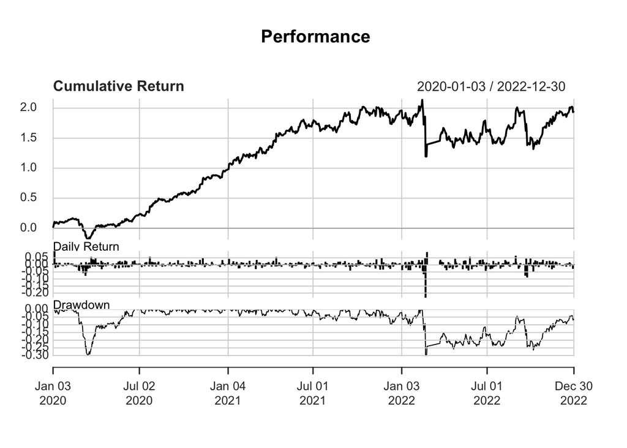

```r
trading_data = trading_data[order(date,-total_rank)]
number_op_positions = 4 # choose number of position
#pnl = trading_data[,mean(next_ret[1:number_op_positions]),by=date]
trading_portfolio = trading_data[,list(symbol = symbol[1:number_op_positions],
                   pnl = next_ret[1:number_op_positions]/number_op_positions,
                   position = 1,
                   total_rank = total_rank[1:number_op_positions]),by=date]

# add cost for each day rebalancing
full_date_symbol = expand.grid(date = unique(trading_portfolio$date),
            symbol = unique(trading_portfolio$symbol))


trading_portfolio = merge(trading_portfolio,full_date_symbol,all = T,by=c('date','symbol'))
trading_portfolio[is.na(position),position:=0]
trading_portfolio[is.na(pnl),pnl:=0]
trading_portfolio[,I_trade:= c(NA,diff(position)),by=symbol]
trading_portfolio[is.na(I_trade),I_trade:=0]
trading_portfolio$pnl = trading_portfolio$pnl - (0.05/100)*abs(trading_portfolio$I_trade)/number_op_positions
ts_portf =  trading_portfolio[,sum(pnl),by='date']

train_pnl = na.omit(xts(ts_portf$V1,order.by = as.Date(ts_portf$date)))
charts.PerformanceSummary(train_pnl['2020/2022'],geometric = T)
```

```r
my_sharpe =  SharpeRatio.annualized(train_pnl['2020/2022'])
my_calmar =  CalmarRatio(train_pnl['2020/2022'])
my_return = Return.annualized(train_pnl['2020/2022'])
my_sharpe
```

```
##                                     [,1]
## Annualized Sharpe Ratio (Rf=0%) 1.430509
```

```r
my_calmar
```

```
##                 [,1]
## Calmar Ratio 1.47082
```

```r
my_return
```

```
##                        [,1]
## Annualized Return 0.4464925
```

## 3. Оценка устойчивости и переобучения

### 3.1 Альтернативная история

```r
alternative_data = data.table()
for(symbol in universe) {
  alternative_data = rbind(alternative_data,
                           getSymbols.Gigapack(symbol, field = 'close, stoch', type = 'tech', fake = T, reps = 10))
  print(symbol)
}
```

Также генерируются альтернативные данные AlgoPack для микроструктурных характеристик:

```r
alternative_algopack = data.table()
for(symbol in universe) {
  alternative_algopack = rbind(alternative_algopack,
                           getSymbols.Gigapack(symbol, field = 'imbalance_vol.median', type = 'candles', fake = T, reps = 10))
  print(symbol)
}
```

### 3.2 Тестирование стратегии на альтернативных данных

Сгенерированные альтернативные данные объединяются и ранжируются по тому же механизму что и на реальных данных.

```r
alternative_data = merge(alternative_data, alternative_algopack, by = c('date', 'symbol', 'sim'))
alternative_data = alternative_data[order(symbol, sim, date)]
alternative_data[, next_ret := shift(close / shift(close, 1) - 1, -1), by = 'symbol, sim']
alternative_data[, imbalance_rank := frank(imbalance_vol.median), by = 'sim, date']
alternative_data[, indicator_rank := frank(stoch), by = 'sim, date']
alternative_data[, total_rank := imbalance_rank + indicator_rank, by = 'sim, date']
alternative_data = alternative_data[order(sim, date, -total_rank)]
alternative_data = na.omit(alternative_data)
```

### 3.3 Оценка стратегии на альтернативных данных

Ровно по тому же признаку оценивается стратегия. только на альтернативных данных.

```r
number_op_positions = 4 # choose number of position
#pnl = trading_data[,mean(next_ret[1:number_op_positions]),by=date]
alternative_portfolio = alternative_data[,list(symbol = symbol[1:number_op_positions],
                                       pnl = next_ret[1:number_op_positions]/number_op_positions,
                                       position = 1,
                                       total_rank = total_rank[1:number_op_positions]),by='sim,date']
# add cost for each day rebalancing
full_date_symbol = expand.grid(date = unique(alternative_portfolio$date),
                               symbol = unique(alternative_portfolio$symbol),
                               sim = unique(alternative_portfolio$sim))

alternative_portfolio = merge(alternative_portfolio,full_date_symbol,all = T,by=c('date','symbol','sim'))

alternative_portfolio[is.na(position),position:=0]
alternative_portfolio[is.na(pnl),pnl:=0]
alternative_portfolio[,I_trade:= c(NA,diff(position)),by='sim,date']
alternative_portfolio[is.na(I_trade),I_trade:=0]

alternative_portfolio$pnl = alternative_portfolio$pnl - (0.05/100)*abs(alternative_portfolio$I_trade)/number_op_positions
#alt_results =  alternative_portfolio[as.Date(date)<'2023-01-01',sum(pnl),by='sim,date']
alt_results =  alternative_portfolio[,sum(pnl),by='sim,date']
```

### 3.4 Сравнение торговых характеристик реального и альтернативного

Формируется портфель и оцениваются торговые показатели на альтернативных данных.

```r
# (Продолжение кода)
# ...

alt_calmar = alt_results[, CalmarRatio(xts(V1, order.by = as.Date(date))), by = sim]
alt_sharpe = alt_results[, SharpeRatio.annualized(xts(V1, order.by = as.Date(date))), by = sim]
alt_return = alt_results[, Return.annualized(xts(V1, order.by = as.Date(date))), by = sim]
library(ggplot2)

ggplot(alt_return, aes(V1 * 100)) + geom_density(fill = 'blue', alpha = .2) + xlim(0, 100) +
  geom_vline(xintercept = 100 * sum(my_return, na.rm = T)) + labs(x = "Sum of PnL, %, 2020-01-01 - 2023-01-01")

ggplot(alt_sharpe, aes(V1)) + geom_density(fill = 'green', alpha = .2) + xlim(0, 3) +
  geom_vline(xintercept = sum(my_sharpe, na.rm = T)) + labs(x = "Sharpe ratio, 2020-01-01 - 2023-01-01")

ggplot(alt_calmar, aes(V1)) + geom_density(fill = 'red', alpha = .2) + xlim(0, 3) +
  geom_vline(xintercept = sum(my_calmar, na.rm = T)) + labs(x = "Calmar, 2020-01-01 - 2023-01-01")
```

Для сравнение гипотетических результатов стратегии (закрашенное распределение) с реальной характеристикой (черная вертикальная линия) используется следующие графики

[figure not shown]

Распределение среднегодовой доходности

[figure not shown]

Распределение коэффициента Шарпа

[figure not shown]

Распределение коэффициента Кальмара

Все реальные характеристики торговой стратегии лежат в границах распределений, что может свидетельствовать о том, что наша стратегия является робастной и не переобученной. Другими словами, оценка переобучения позволяет убедиться в том, что стратегия демонстрирует стабильность и эффективность не только на реальных данных, но и на сгенерированных, что является важным фактором при принятии решения о применении стратегии в реальных условиях рынка.

### 3.5. Подводя итоги

Таким образом в ходе данного исследования мы не просто разработали торговую стратегию на основе данных AlgoPack, но и продемонстрировали практический подход к оценке и отбору торговых стратегий. Альтернативные данные позволяют оценить степень достоверности и робастности торговых стратегий. Стратегия GigaMomentum получилась надежной стратегией которая устойчиво работает как на периоде обучения, так и на данных которых не было в рынке (чистый out of sample)

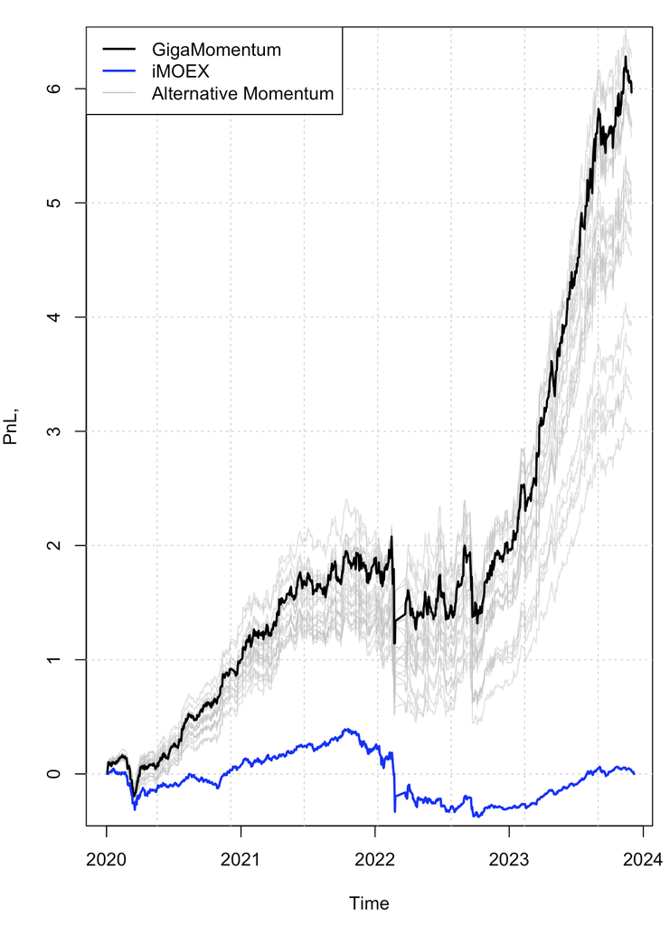

Динамика Giga Momentum и его гипотетических сценариев по сравнению с индексом ММВБ